# geomorph_final

### Normality check

We used Shapiro-Wilk tests, histograms, and QQ plots to determine what traits were normal, and performed transformations as needed. The original raw data set was separated into the two factors of interest: digital and manual measurements.

```r
digital <- raw %>%
  select(ID, SPP, ends_with(".dig"))

manual <- raw %>%
  select(ID, SPP, ends_with(".man"))
```

#### *Digital*

All but OL fail the Shapiro-Wilk test with a slight skew/deviation to the right.

```r
vars.dig <- c("SL.dig","BD1.dig", "BD2.dig","CPD.dig","CPL.dig","PreDL.dig",
              "DbL.dig","HL.dig","HD1.dig", "HD2.dig","SnL.dig","OL.dig")

##### Shapiro-Wilk test #####
shapiro.results.dig <- data.frame(
  Variable = character(),
  W = numeric(),
  p.value = numeric(),
  stringsAsFactors = FALSE)

for(v in vars.dig){
  x <- digital[[v]]


    test <- shapiro.test(x)
    shapiro.results.dig <- rbind(shapiro.results.dig,
                             data.frame(Variable = v,
                                        W = test$statistic,
                                        p.value = test$p.value))}


shapiro.results.dig
```

```
##      Variable         W      p.value
## W      SL.dig 0.9747288 1.162855e-05
## W1    BD1.dig 0.9819629 2.964423e-04
## W2    BD2.dig 0.9907001 3.068655e-02
## W3    CPD.dig 0.9647156 2.595026e-07
## W4    CPL.dig 0.9544425 9.411295e-09
## W5  PreDL.dig 0.9815262 2.403116e-04
## W6    DbL.dig 0.9864009 2.819981e-03
## W7     HL.dig 0.9524257 5.178922e-09
## W8    HD1.dig 0.9764995 2.458179e-05
## W9    HD2.dig 0.9714766 3.137461e-06
## W10   SnL.dig 0.9721834 4.142796e-06
## W11    OL.dig 0.9960927 5.701102e-01
```

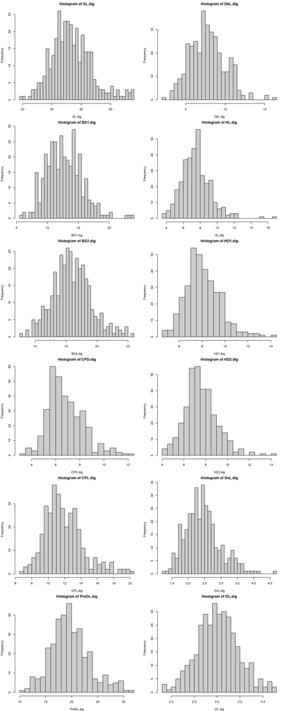

```r
##### Histograms #####

par(mfcol = c(6, 2),
    mar = c(4,4,2,1))

for(v in vars.dig){

  hist(digital[[v]],
       main = paste("Histogram of", v),
       xlab = v,
       breaks = 30,
       col = "gray80",
       border = "black")}
```

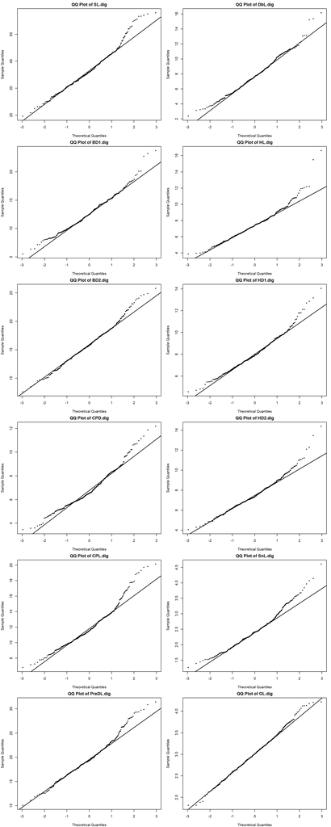

```r
##### QQ plots #####

par(mfcol = c(6, 2),
    mar = c(4,4,2,1))

for(v in vars.dig){
  x <- digital[[v]]

 qqnorm(x,
         main = paste("QQ Plot of", v),
         pch = 16, cex = 0.6)
  qqline(x, lwd = 1.5)}
```

#### *Manual*

All fail the SW test, with a slight skew/deviation to the right.

```r
vars.man <- c("SL.man","BD1.man","CPD.man","CPL.man","PreDL.man",
              "DbL.man","HL.man","HD1.man","SnL.man","OL.man")

##### Shapiro-Wilk test #####
shapiro.results.man <- data.frame(
  Variable = character(),
  W = numeric(),
  p.value = numeric(),
  stringsAsFactors = FALSE)

for(v in vars.man){
  x <- manual[[v]]


    test <- shapiro.test(x)
    shapiro.results.man <- rbind(shapiro.results.man,
                             data.frame(Variable = v,
                                        W = test$statistic,
                                        p.value = test$p.value))}


shapiro.results.man
```

```
##     Variable         W      p.value
## W     SL.man 0.9803600 1.385246e-04
## W1   BD1.man 0.9649400 2.806364e-07
## W2   CPD.man 0.9703722 2.046467e-06
## W3   CPL.man 0.9742701 9.619237e-06
## W4 PreDL.man 0.9803693 1.391285e-04
## W5   DbL.man 0.9834650 6.199508e-04
## W6    HL.man 0.9703235 2.008697e-06
## W7   HD1.man 0.9837772 7.249281e-04
## W8   SnL.man 0.9761470 2.113414e-05
## W9    OL.man 0.9882780 7.818149e-03
```

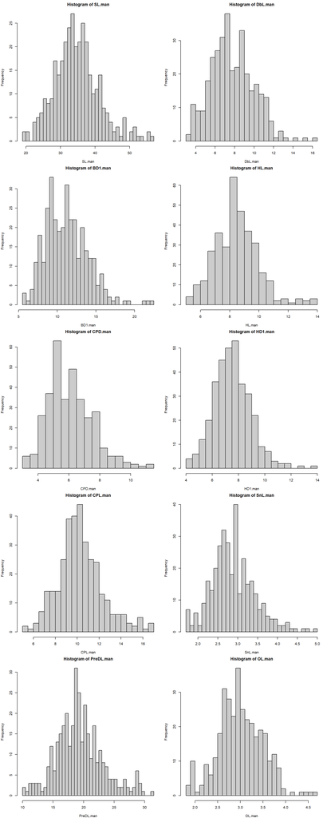

```r
##### Histograms #####

par(mfcol = c(5, 2),
    mar = c(4,4,2,1))

for(v in vars.man){

  hist(manual[[v]],
       main = paste("Histogram of", v),
       xlab = v,
       breaks = 30,
       col = "gray80",
       border = "black")}
```

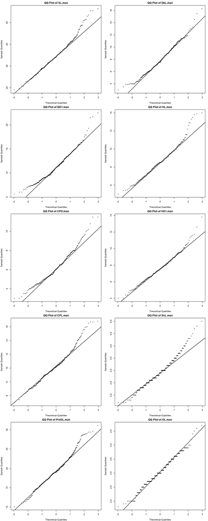

```r
##### QQ plots #####

par(mfcol = c(5, 2),
    mar = c(4,4,2,1))

for(v in vars.man){
  x <- manual[[v]]

 qqnorm(x,
         main = paste("QQ Plot of", v),
         pch = 16, cex = 0.6)
  qqline(x, lwd = 1.5)}
```

#### Log transform & recheck

Orbital length (OL) was normal in the raw check of the digital measurements, but since it was not normal in manual measurements, and I want to compare the two data sets, I will transform the digital OL data.

Log transformed data sets

```r
dig_trans <- digital
dig_trans[, c(3:14)] <- log(dig_trans[, c(3:14)])

man_trans <- manual
man_trans[, c(3:12)] <- log(man_trans[, c(3:12)])
```

##### *Digital Recheck*

```r
##### Shapiro-Wilk test #####
shapiro.results.dig2 <- data.frame(
  Variable = character(),
  W = numeric(),
  p.value = numeric(),
  stringsAsFactors = FALSE)

for(v in vars.dig){
  x <- dig_trans[[v]]


    test <- shapiro.test(x)
    shapiro.results.dig2 <- rbind(shapiro.results.dig2,
                             data.frame(Variable = v,
                                        W = test$statistic,
                                        p.value = test$p.value))}


shapiro.results.dig2
```

```
##      Variable         W      p.value
## W      SL.dig 0.9940337 0.2053198029
## W1    BD1.dig 0.9938056 0.1810552710
## W2    BD2.dig 0.9897775 0.0181244706
## W3    CPD.dig 0.9918688 0.0601270564
## W4    CPL.dig 0.9911582 0.0399269006
## W5  PreDL.dig 0.9924748 0.0852084432
## W6    DbL.dig 0.9842555 0.0009232117
## W7     HL.dig 0.9912957 0.0432145697
## W8    HD1.dig 0.9968683 0.7577338059
## W9    HD2.dig 0.9947836 0.3065509900
## W10   SnL.dig 0.9973240 0.8577685652
## W11    OL.dig 0.9898953 0.0193785868
```

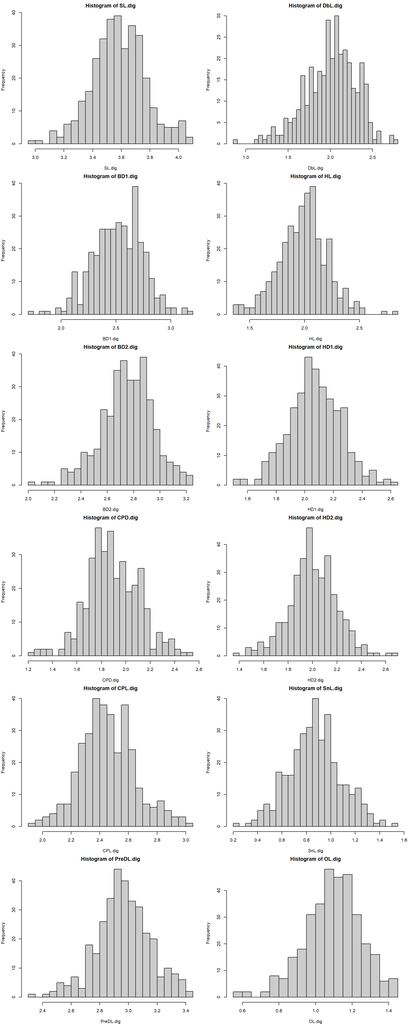

```r
##### Histograms #####

par(mfcol = c(6, 2),
    mar = c(4,4,2,1))

for(v in vars.dig){

  hist(dig_trans[[v]],
       main = paste("Histogram of", v),
       xlab = v,
       breaks = 30,
       col = "gray80",
       border = "black")}
```

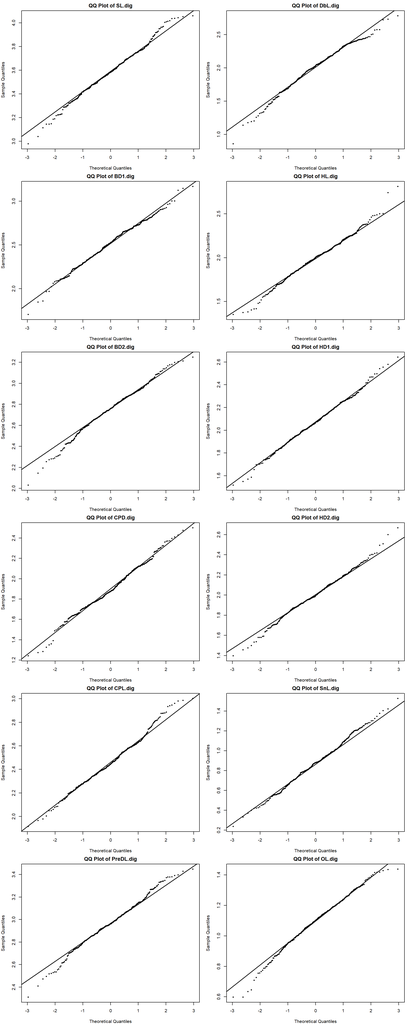

```r
##### QQ plots #####

par(mfcol = c(6, 2),
    mar = c(4,4,2,1))

for(v in vars.dig){
  x <- dig_trans[[v]]

 qqnorm(x,
         main = paste("QQ Plot of", v),
         pch = 16, cex = 0.6)
  qqline(x, lwd = 1.5)}
```

##### *Manual Recheck*

```r
##### Shapiro-Wilk test #####
shapiro.results.man2 <- data.frame(
  Variable = character(),
  W = numeric(),
  p.value = numeric(),
  stringsAsFactors = FALSE)

for(v in vars.man){
  x <- man_trans[[v]]


    test <- shapiro.test(x)
    shapiro.results.man2 <- rbind(shapiro.results.man2,
                             data.frame(Variable = v,
                                        W = test$statistic,
                                        p.value = test$p.value))}


shapiro.results.man2
```

```
##     Variable         W      p.value
## W     SL.man 0.9942395 0.2296844800
## W1   BD1.man 0.9956743 0.4746692106
## W2   CPD.man 0.9959766 0.5428078688
## W3   CPL.man 0.9896569 0.0169264045
## W4 PreDL.man 0.9869188 0.0037215570
## W5   DbL.man 0.9884938 0.0088119649
## W6    HL.man 0.9908068 0.0326245092
## W7   HD1.man 0.9926432 0.0938495965
## W8   SnL.man 0.9903341 0.0248848419
## W9    OL.man 0.9798076 0.0001072263
```

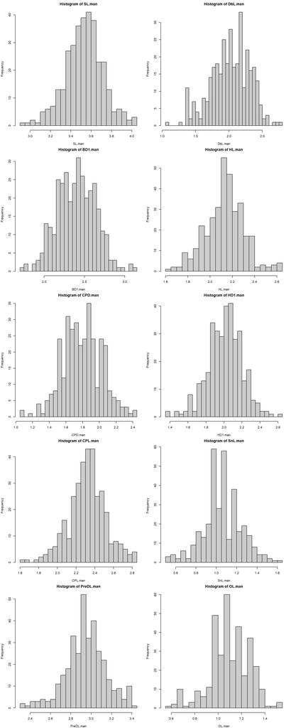

```r
##### Histograms #####

par(mfcol = c(5, 2),
    mar = c(4,4,2,1))

for(v in vars.man){

  hist(man_trans[[v]],
       main = paste("Histogram of", v),
       xlab = v,
       breaks = 30,
       col = "gray80",
       border = "black")}
```

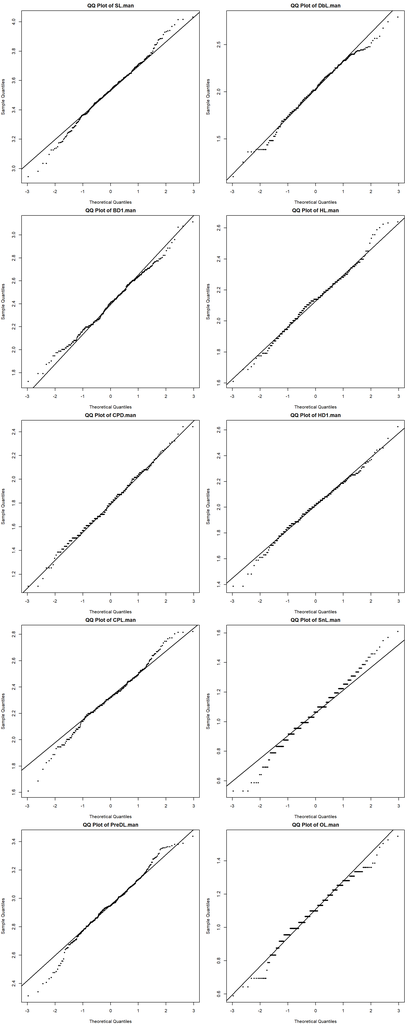

```r
##### QQ plots #####

par(mfcol = c(5, 2),
    mar = c(4,4,2,1))

for(v in vars.man){
  x <- man_trans[[v]]

 qqnorm(x,
         main = paste("QQ Plot of", v),
         pch = 16, cex = 0.6)
  qqline(x, lwd = 1.5)}
```

### Formatting

I will perform 3 different analyses: Bland-Altman (BA), MANOVA and PCA. These vary in whether they need long or wide formats. Also, the raw data contains columns that are not needed for these analyses (eg location or photo date) so I will remove those to leave just the species, tag ID, and measurements.

Additionally, since we have two measurements for BD and HD, we will create two datasets: one with BD1 and HD1, and another with BD2 and HD2 (this applies to digital only, as manual only has one measurement for each). Once we run BA plots, we can determine which of these measurements is best to continue analysis with.

**Long format**

```r
#log transform entire data set

raw2 <- raw
raw2[, c(3:24)] <- log(raw2[, c(3:24)])

# this will create a data frame with species, ID, characteristic, method and value
df_long <- raw2 %>%
  pivot_longer(
    cols = ends_with(".dig") | ends_with(".man"),
    names_to = c("characteristic", "method"),
    names_sep = "\\.",
    values_to = "value"
  )

# method and characteristic are initially a character; need to be a factor
df_long$method <- as.factor(df_long$method)
df_long$characteristic <- as.factor(df_long$characteristic)


#create data frames that only have one measurement for BD and HD

## BD1 and HD1 for both digital and manual measurements
df_long2 <- df_long[-grep("BD2", df_long$characteristic),]
df_long2 <- df_long2[-grep("HD2", df_long2$characteristic),]#only contains BD1 & HD1

## BD1/HD1 for manual (since they only have one) and BD2/HD2 for digital
df_long3 <- df_long %>%
    filter(
    # Keep everything for Hand measurements
    method == "man" |
    # Keep all digital measurements except BD1 and HD1
    !(method == "dig" & characteristic %in% c("BD1", "HD1"))
  )

#to ensure comparisons between BD2 and BD1 in this new data frame, will combine characteristic names to just BD or HD

df_long3<- df_long3 %>%
  mutate(
    characteristic = case_when(
      characteristic %in% c("BD1", "BD2") ~ "BD",
      characteristic %in% c("HD1", "HD2") ~ "HD",
      TRUE ~ characteristic  # Leave other characteristics unchanged
    )
  )
```

**Wide format**

```r
df_wide <- df_long2 %>%
  pivot_wider(
    names_from = method,
    values_from = value
  )


df_wide2 <- df_long3 %>%
  pivot_wider(
    names_from = method,
    values_from = value
  )
```

## **Bland-Altman Plot**

Used to assess agreement between two measurement methods.

### BD/HD plots

We’re first interested in how BD1, HD1, BD2, and HD2 compare, so we isolated those.

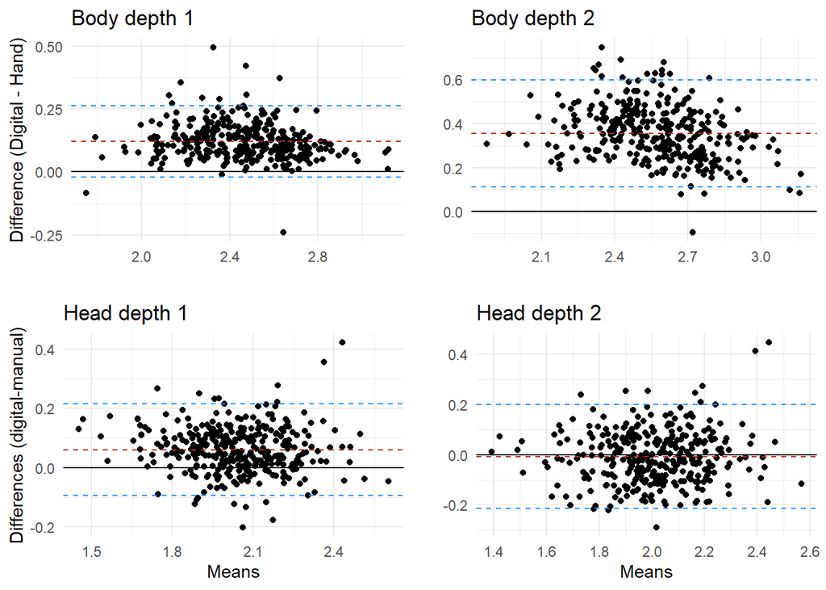

```r
## Isolate data for each characteristic (BD1, BD2, HD1, HD2)
data_BD1 <- df_wide %>%
  filter(characteristic == "BD1")
data_BD1 <- data_BD1 %>%
  mutate(
    average = (dig + man) / 2,
    difference = dig - man)


data_HD1 <- df_wide %>%
  filter(characteristic == "HD1")
data_HD1 <- data_HD1 %>%
  mutate(
    average = (dig + man) / 2,
    difference = dig - man)


data_BD2 <- df_wide2 %>%
  filter(characteristic == "BD")
data_BD2 <- data_BD2 %>%
  mutate(
    average = (dig + man) / 2,
    difference = dig - man)


data_HD2 <- df_wide2 %>%
  filter(characteristic == "HD")
data_HD2 <- data_HD2 %>%
  mutate(
    average = (dig + man) / 2,
    difference = dig - man)


## Create Bland-Altman plots for each characteristic

ba.BD1 <- blandr.draw(data_BD1$dig, data_BD1$man, ciDisplay = FALSE) +
  geom_hline(yintercept = mean(data_BD1$difference, na.rm = TRUE), color = "#b22d11", linetype = "dashed") +  # Mean line
  geom_hline(yintercept = mean(data_BD1$difference, na.rm = TRUE) + c(-1.96, 1.96) * sd(data_BD1$difference, na.rm = TRUE),
             color = "dodgerblue", linetype = "dashed") +  # Limits of agreement
  labs(title = "Body depth 1",
       x = "",
       y = "Difference (Digital - Hand)") +
  theme_minimal()
#ba.BD1


ba.BD2 <- blandr.draw(data_BD2$dig, data_BD2$man, ciDisplay = FALSE) +
  geom_hline(yintercept = mean(data_BD2$difference, na.rm = TRUE), color = "#b22d11", linetype = "dashed") +  # Mean line
  geom_hline(yintercept = mean(data_BD2$difference, na.rm = TRUE) + c(-1.96, 1.96) * sd(data_BD2$difference, na.rm = TRUE),
             color = "dodgerblue", linetype = "dashed") +  # Limits of agreement
  labs(title = "Body depth 2",
       x = "",
       y = "") +
  theme_minimal()
#ba.BD2


ba.HD1 <- blandr.draw(data_HD1$dig, data_HD1$man, ciDisplay = FALSE) +
  geom_hline(yintercept = mean(data_HD1$difference, na.rm = TRUE), color = "#b22d11", linetype = "dashed") +  # Mean line
  geom_hline(yintercept = mean(data_HD1$difference, na.rm = TRUE) + c(-1.96, 1.96) * sd(data_HD1$difference, na.rm = TRUE),
             color = "dodgerblue", linetype = "dashed") +  # Limits of agreement
  labs(title = "Head depth 1",
       x = "Means",
       y = "Differences (digital-manual)") +
  theme_minimal()
#ba.HD1


ba.HD2 <- blandr.draw(data_HD2$dig, data_HD2$man, ciDisplay = FALSE) +
  geom_hline(yintercept = mean(data_HD2$difference, na.rm = TRUE), color = "#b22d11", linetype = "dashed") +  # Mean line
  geom_hline(yintercept = mean(data_HD2$difference, na.rm = TRUE) + c(-1.96, 1.96) * sd(data_HD2$difference, na.rm = TRUE),
             color = "dodgerblue", linetype = "dashed") +  # Limits of agreement
  labs(title = "Head depth 2",
       x = "Means",
       y = "") +
  theme_minimal()
#ba.HD2


plots.BDHD <- grid.arrange(ba.BD1, ba.BD2, ba.HD1, ba.HD2)
```

```r
plots.BDHD
```

```r
ggsave(plots.BDHD, filename = "SFig3_BDHD-BA-plots.png")
```

We see that BD1 has less scatter, less outside the limits of agreement (blue dashed lines; LOA) and a smaller bias compared to BD2 (red dashed line; 0.12 vs 0.36 respectively). In addition, BD2’s LOA don’t include 0, so BD1 is more appropriate to use. In contrast, HD1, while it has less scatter with fewer points outside the LOA, it has a bias further away from 0 compared to HD2 (red dashed line; 0.06 vs -0.008 respectively), so HD2 is more appropriate to use.

I will therefore create a final data set with BD1 and HD2 for all subsequent analyses.

### BA plots

#### *All traits*

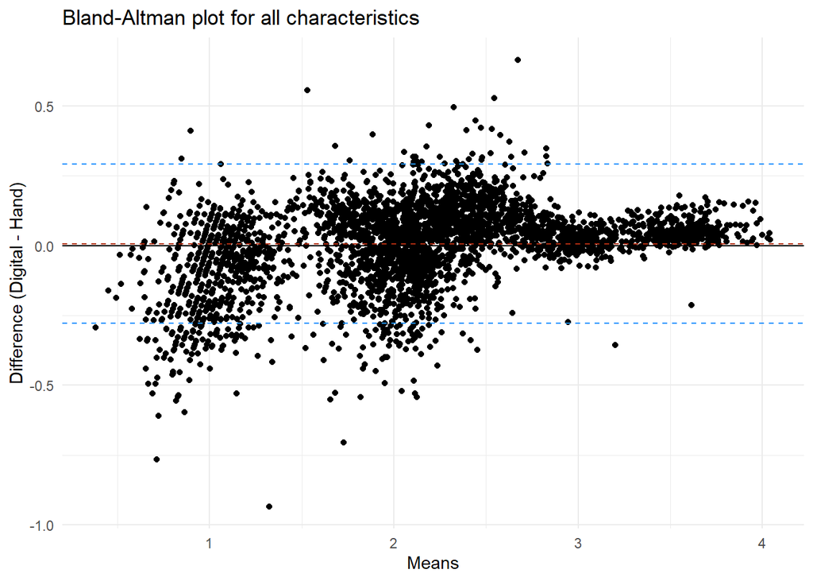

```r
df_ba_fin <- df_wide_fin %>%
  mutate(
    average = (dig + man) / 2,
    difference = dig - man
  )

ba_full_fin <- blandr.draw(df_ba_fin$dig, df_ba_fin$man, ciDisplay = FALSE) +
  geom_hline(yintercept = mean(df_ba_fin$difference, na.rm = TRUE), color = "#b22d11", linetype = "dashed") +  # Mean line
  geom_hline(yintercept = mean(df_ba_fin$difference, na.rm = TRUE) + c(-1.96, 1.96) * sd(df_ba_fin$difference, na.rm = TRUE),
             color = "dodgerblue", linetype = "dashed") +  # Limits of agreement
  labs(title = "Bland-Altman plot for all characteristics",
       x = "Means",
       y = "Difference (Digital - Hand)") +
  theme_minimal()

ba_full_fin
```

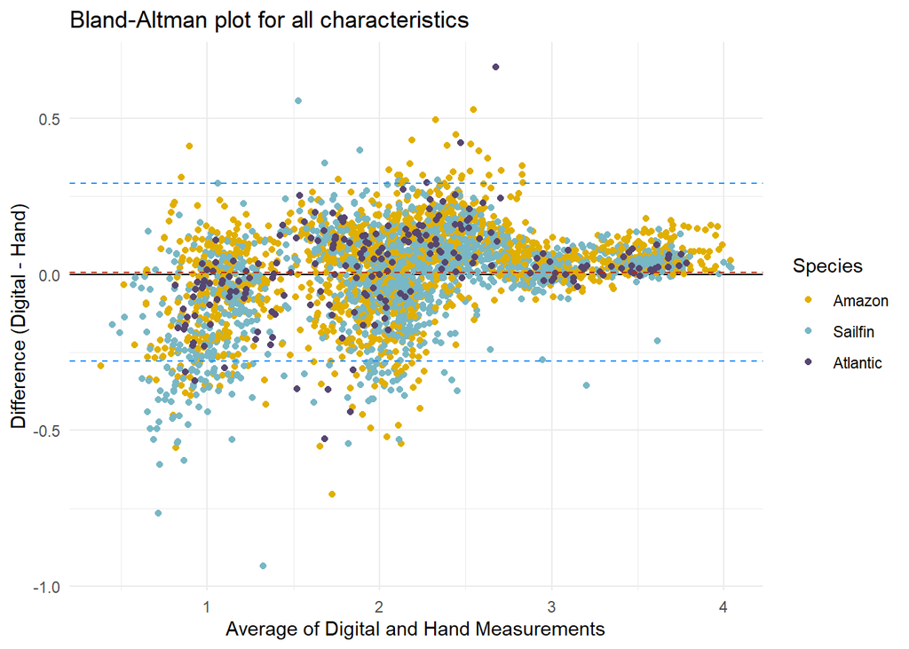

```r
##### By species

ba_full_SPP_fin <- blandr.draw(df_ba_fin$dig, df_ba_fin$man, ciDisplay = FALSE) +
  geom_point(data = df_ba_fin, aes(color=SPP)) +
  scale_color_manual(
    name = "Species",
    values=c("#E1AF00","#78B7C5", "#564670"),
    labels = c("Amazon", "Sailfin", "Atlantic")) +
  geom_hline(yintercept = mean(df_ba_fin$difference, na.rm = TRUE), color = "#b22d11", linetype = "dashed") +  # Mean line
  geom_hline(yintercept = mean(df_ba_fin$difference, na.rm = TRUE) + c(-1.96, 1.96) * sd(df_ba_fin$difference, na.rm = TRUE),
             color = "dodgerblue", linetype = "dashed") +  # Limits of agreement
  labs(title = "Bland-Altman plot for all characteristics",
       x = "Average of Digital and Hand Measurements",
       y = "Difference (Digital - Hand)") +
  theme_minimal()

ba_full_SPP_fin
```

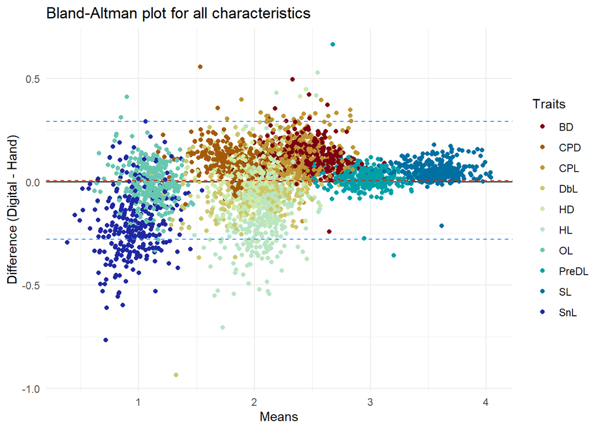

```r
##### By characteristics

ba_full_CR_fin <- blandr.draw(df_ba_fin$dig, df_ba_fin$man, ciDisplay = FALSE) +
  geom_point(data = df_ba_fin, aes(color=characteristic)) +
  scale_color_manual(
    name = "Traits",
    values= hcl.colors(10, palette = "Roma")) +
  geom_hline(yintercept = mean(df_ba_fin$difference, na.rm = TRUE), color = "#b22d11", linetype = "dashed") +  # Mean line
  geom_hline(yintercept = mean(df_ba_fin$difference, na.rm = TRUE) + c(-1.96, 1.96) * sd(df_ba_fin$difference, na.rm = TRUE),
             color = "dodgerblue", linetype = "dashed") +  # Limits of agreement
  labs(title = "Bland-Altman plot for all characteristics",
       x = "Means",
       y = "Difference (Digital - Hand)") +
  theme_minimal()

ba_full_CR_fin
```

```r
ggsave(ba_full_CR_fin, filename= "Fig6a_BA-full.png")
```

#### *By trait*

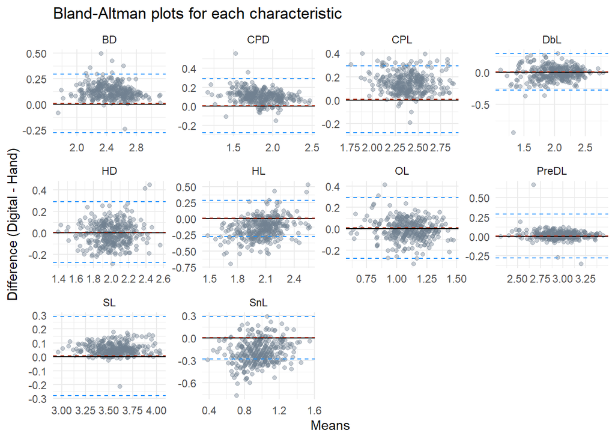

```r
# NOTE: could not figure out how to facet wrap with blandr.draw, so created a Bland-Altman plot through ggplot instead

ba_by_char_fin <- ggplot(df_ba_fin, aes(x = average, y = difference)) +
  geom_point(color= "slategrey", alpha = 0.4) +
  geom_hline(yintercept = 0, linetype = "solid", color = "black") +
  geom_hline(yintercept = mean(df_ba_fin$difference, na.rm = TRUE), color = "#b22d11", linetype = "dashed") +  # Mean line
  geom_hline(yintercept = mean(df_ba_fin$difference, na.rm = TRUE) + c(-1.96, 1.96) * sd(df_ba_fin$difference, na.rm = TRUE),
             color = "dodgerblue", linetype = "dashed") +  # Limits of agreement
  labs(title = "Bland-Altman plots for each characteristic",
       x = "Means",
       y = "Difference (Digital - Hand)") +
  facet_wrap(~ characteristic, scales = "free") +
  theme_minimal()


ba_by_char_fin
```

```r
ggsave(ba_by_char_fin, filename = "Fig6b_BA-by-trait.png")
```

### BA Stats

```r
### Whole data set

(bar_full <- blandr.statistics(df_wide_fin$dig, df_wide_fin$man))
```

```
## Bland-Altman Statistics
## =======================
## t = 2.6493, df = 3389, p-value = 0.008104
## alternative hypothesis: true bias is not equal to 0
##
## =======================
## Number of comparisons:  3390
## Maximum value for average measures:  4.042436
## Minimum value for average measures:  0.3834636
## Maximum value for difference in measures:  0.6657775
## Minimum value for difference in measures:  -0.9342704
##
## Bias:  0.006609047
## Standard deviation of bias:  0.145248
##
## Standard error of bias:  0.002494654
## Standard error for limits of agreement:  0.004263812
##
## Bias:  0.006609047
## Bias- upper 95% CI:  0.01150023
## Bias- lower 95% CI:  0.001717868
##
## Upper limit of agreement:  0.2912951
## Upper LOA- upper 95% CI:  0.299655
## Upper LOA- lower 95% CI:  0.2829352
##
## Lower limit of agreement:  -0.278077
## Lower LOA- upper 95% CI:  -0.2697171
## Lower LOA- lower 95% CI:  -0.2864369
##
## =======================
## Derived measures:
## Mean of differences/means:  -1.171216
## Point estimate of bias as proportion of lowest average:  1.723514
## Point estimate of bias as proportion of highest average 0.1634917
## Spread of data between lower and upper LoAs:  0.5693721
## Bias as proportion of LoA spread:  1.160761
##
## =======================
## Bias:
##  0.006609047  ( 0.001717868  to  0.01150023 )
## ULoA:
##  0.2912951  ( 0.2829352  to  0.299655 )
## LLoA:
##  -0.278077  ( -0.2864369  to  -0.2697171 )
```

```r
### By characteristic

ba_stats_all <- df_wide_fin %>%
  group_by(characteristic) %>%
  summarise(
    stats = list(blandr.statistics(dig, man)),
    .groups = "drop") %>%
  rowwise() %>%
  mutate(
    t_value = stats$bias / stats$biasSEM,
    p_value = 2 * pt(-abs(stats$bias / stats$biasSEM), df = stats$no.of.observations - 1),
    bias_CI = paste0(round(stats$bias,3),
                     " (", round(stats$biasLowerCI,3),
                     ", ", round(stats$biasUpperCI,3), ")"),
    LOA_range = paste0(round(stats$lowerLOA,3), " to ", round(stats$upperLOA,3))) %>%
    mutate(p_display = case_when(
    p_value < 0.001 ~ "*p* < 0.001^*^",
    p_value < 0.05  ~ paste0(sprintf("%.3f", p_value), "^*^"),
    TRUE            ~ sprintf("%.3f", p_value))) %>%
  ungroup()

ba.stats.char <- ba_stats_all %>%
  select(characteristic, t_value, p_value, p_display, bias_CI, LOA_range) %>%
  gt() %>%
  cols_hide(columns = p_value) %>%
  tab_header(title = "Bland–Altman Statistics by Trait") %>%
  cols_label(
    characteristic = "Trait",
    t_value = "t value",
    p_display = "p-value",
    bias_CI = "Bias (CI)",
    LOA_range = "Limit of Agreement Range") %>%
  fmt_markdown(columns = p_display) %>%
  fmt_number(columns = c(t_value), decimals = 3) %>%
  tab_style(
    style = cell_borders(sides = "right", color = "lightgray", weight = px(1.5)),
    locations = cells_body(columns = c(characteristic, t_value, p_display, bias_CI))) %>%
  cols_align(
    align = "center",
    columns = everything()) %>%
  tab_style(
    style = cell_text(weight = "bold"),
    locations = cells_body(
      columns = "p_display",
      rows = p_value < 0.05))
ba.stats.char
```

Bland–Altman Statistics by Trait

| Trait | t value | p-value | Bias (CI) | Limit of Agreement Range |
| --- | --- | --- | --- | --- |
| BD | 30.613 | *p* < 0.001* | 0.121 (0.113, 0.129) | -0.022 to 0.263 |
| CPD | 27.399 | *p* < 0.001* | 0.102 (0.094, 0.109) | -0.032 to 0.235 |
| CPL | 30.740 | *p* < 0.001* | 0.141 (0.132, 0.15) | -0.025 to 0.306 |
| DbL | −2.844 | 0.005* | -0.017 (-0.029, -0.005) | -0.236 to 0.201 |
| HD | −1.370 | 0.172 | -0.008 (-0.019, 0.003) | -0.215 to 0.199 |
| HL | −16.152 | *p* < 0.001* | -0.143 (-0.161, -0.126) | -0.464 to 0.177 |
| OL | −1.765 | 0.078 | -0.009 (-0.019, 0.001) | -0.196 to 0.178 |
| PreDL | 5.133 | *p* < 0.001* | 0.016 (0.01, 0.023) | -0.099 to 0.132 |
| SL | 23.921 | *p* < 0.001* | 0.054 (0.049, 0.058) | -0.027 to 0.135 |
| SnL | −22.083 | *p* < 0.001* | -0.19 (-0.207, -0.173) | -0.5 to 0.12 |

```r
gtsave(ba.stats.char, "Table7_ba-stats-char.png")
```

```
## file:///C:/Users/allis/AppData/Local/Temp/RtmpAlID5K/file87b42c11403b.html screenshot completed
```

While p-values for the whole data set and just about all of the characteristics are significant, we see that the bias itself is incredibly close to zero. The significant t-test may be a result of very little deviation overall, so any small deviation that does exist is flagged as significant. However, due to the biases being so close to zero, and the LOAs including zero, we feel that any significant difference is not methodologically relevant (ie there is not actual difference in methods).

## **MANOVA**

We will run a repeated measures MANOVA on our data to corroborate our Bland-Altman results. We will follow up our MANOVA with an effect size calculation to see if any statistical significance is methodologically relevant.

### Data frame

First, need a data frame with two rows per individual (one for digital and one for manual), plus 10 columns corresponding to each characteristic. Will create new long/wide formats since the ones above don’t have separate columns for the characteristics.

```r
raw3 <- raw2 %>%
  rename(HD.dig = HD2.dig, HD.man = HD1.man)

raw3<- raw3[-5] #removes BD2
raw3<- raw3[-10] #removes HD1 for digital

df_long_ex <- raw3 %>%
  pivot_longer(cols = -c(ID, SPP),
               names_to = "Measurement",
               values_to = "Value") %>%
  mutate(Method = ifelse(str_detect(Measurement, ".dig"), "Digital", "Manual"),
         Character = str_remove_all(Measurement, ".dig|.man")) %>%
  select(ID, Method, Character, Value)

df_wide_ex <- df_long_ex %>%
  pivot_wider(names_from = Character, values_from = Value)
```

### Results

Similar to our BA stats, we see a significant but not practical difference between methods. The MANOVA is statistically significant (p<0.001) but have a small effect size (0.0267). This means that method only explains 2.67% of the variance in our data.

```r
manova_mod <- manova(cbind(SL, BD1, CPD, CPL, PreDL, DbL, HL, HD, SnL, OL) ~ Method + Error(ID/Method), data=df_wide_ex)

summary(manova_mod, test= "Pillai")
```

```
##
## Error: ID
##            Df Pillai approx F num Df den Df Pr(>F)
## Residuals 338
##
## Error: ID:Method
##            Df  Pillai approx F num Df den Df    Pr(>F)
## Method      1 0.90343   307.77     10    329 < 2.2e-16 ***
## Residuals 338
## ---
## Signif. codes:  0 '***' 0.001 '**' 0.01 '*' 0.05 '.' 0.1 ' ' 1
```

```r
# resutls from summary
pillai_method <- 0.90343
num_df_method <- 10
den_df_method <- 329

# Calculate partial eta-squared for Method
eta_squared_method <- pillai_method / (pillai_method + (den_df_method / num_df_method))

# Print the result
cat("Partial Eta-Squared (Method):", eta_squared_method, "\n")
```

```
## Partial Eta-Squared (Method): 0.02672599
```

## **PCA**

In this analysis, I will compare the principle components after centering and scaling the data. A PCA analysis will help us determine which methodology influences the variation in our data the most without worrying about differences in scales/measurements.

### Data sets

In order to create ellipses around each method, we need to create a data frame where we have a method column.

```r
z.scores <- raw3

z.scores[, c(3:22)] <- scale(z.scores[, 3:22], center = TRUE, scale = TRUE)

z.long <- z.scores %>%
  pivot_longer(cols = -c(ID, SPP),
               names_to = "Measurement",
               values_to = "Value") %>%
  mutate(Method = ifelse(str_detect(Measurement, ".dig"), "Digital", "Manual"),
         Character = str_remove_all(Measurement, ".dig|.man")) %>%
  select(ID, Method, Character, Value)

z.wide <- z.long %>%
  pivot_wider(names_from = Character, values_from = Value)
```

### Loadings

```r
PCA_z <- prcomp(z.wide[, 3:12])

summary(PCA_z)
```

```
## Importance of components:
##                           PC1    PC2     PC3     PC4     PC5     PC6     PC7
## Standard deviation     2.8436 0.8130 0.62614 0.55854 0.46266 0.33455 0.26840
## Proportion of Variance 0.8098 0.0662 0.03926 0.03124 0.02144 0.01121 0.00721
## Cumulative Proportion  0.8098 0.8760 0.91527 0.94652 0.96795 0.97916 0.98638
##                            PC8     PC9   PC10
## Standard deviation     0.26010 0.23545 0.1137
## Proportion of Variance 0.00678 0.00555 0.0013
## Cumulative Proportion  0.99315 0.99870 1.0000
```

```r
(loadings_z <- PCA_z$rotation[, 1:5])
```

```
##              PC1          PC2          PC3         PC4         PC5
## SL    -0.3445531 -0.114345286 -0.005710169  0.17154564  0.19310638
## BD1   -0.3316972  0.156767306  0.075155460  0.22928394  0.04281623
## CPD   -0.3386258  0.053705753  0.069041230  0.14616615  0.12970500
## CPL   -0.3296284 -0.169510427  0.005859031  0.20431984  0.38364527
## PreDL -0.3169342 -0.437246343 -0.116280333  0.19844760  0.16662862
## DbL   -0.2576666  0.798347380  0.229640535  0.01923739  0.07996431
## HL    -0.3043295  0.001361965 -0.484743514 -0.68113463  0.02637547
## HD    -0.3333319  0.135633642 -0.223446752 -0.26299302 -0.01135247
## SnL   -0.2814261 -0.288741515  0.771066560 -0.43214578 -0.23115811
## OL    -0.3133228 -0.020449151 -0.209317400  0.30867235 -0.84169568
```

```r
(z.eig.val <- get_eigenvalue(PCA_z)) # We will keep the first two PCs (explains ~88% of variation)
```

```
##        eigenvalue variance.percent cumulative.variance.percent
## Dim.1  8.08619177       80.9815360                    80.98154
## Dim.2  0.66098035        6.6195814                    87.60112
## Dim.3  0.39204658        3.9262653                    91.52738
## Dim.4  0.31196561        3.1242710                    94.65165
## Dim.5  0.21405644        2.1437310                    96.79538
## Dim.6  0.11192433        1.1208990                    97.91628
## Dim.7  0.07204117        0.7214774                    98.63776
## Dim.8  0.06765296        0.6775304                    99.31529
## Dim.9  0.05543776        0.5551977                    99.87049
## Dim.10 0.01293197        0.1295110                   100.00000
```

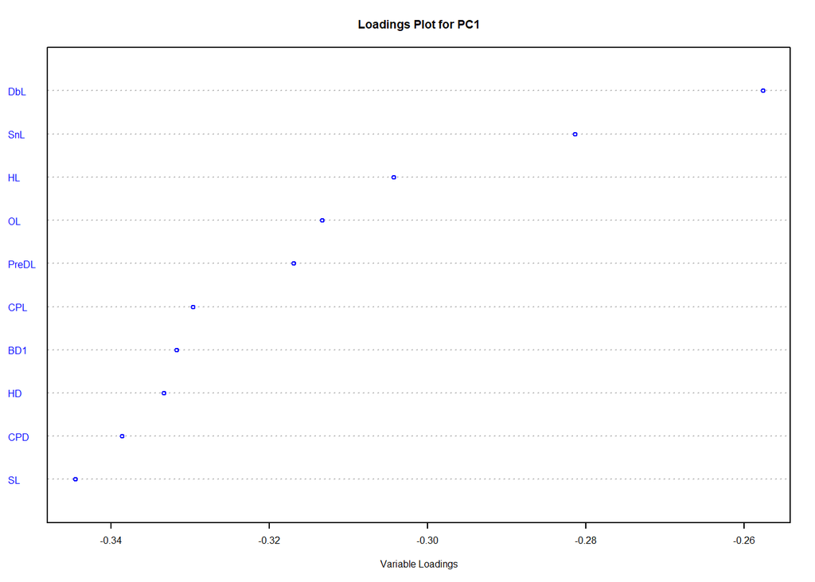

```r
z.ind <- get_pca_ind(PCA_z)

z.wide <- cbind(z.wide, z.ind$coord[,1:2])


z.sorted.loadings.1 <- loadings_z[order(loadings_z[, 1]), 1]
z.myTitle <- "Loadings Plot for PC1"
z.myXlab  <- "Variable Loadings"
dotchart(z.sorted.loadings.1, main=z.myTitle, xlab=z.myXlab, cex=0.5, col="blue")
```

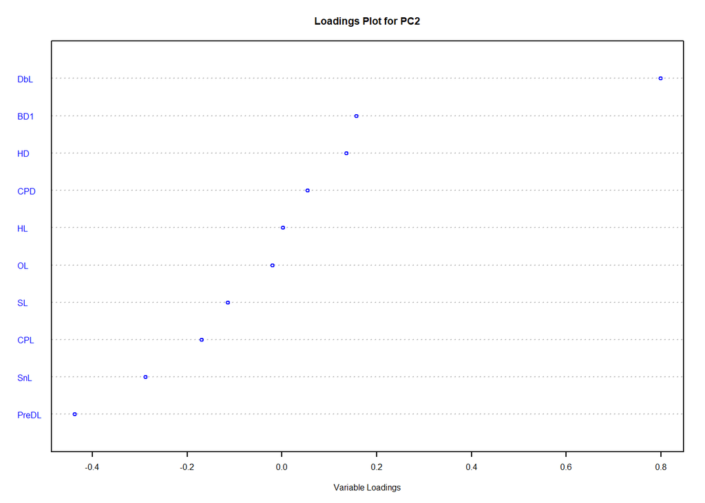

```r
z.sorted.loadings.2 <- loadings_z[order(loadings_z[, 2]), 2]
z.myTitle <- "Loadings Plot for PC2"
z.myXlab  <- "Variable Loadings"
dotchart(z.sorted.loadings.2, main=z.myTitle, xlab=z.myXlab, cex=0.5, col="blue")
```

### Post PCA Tests

We will now make comparisons between the two methods using both t-tests and Levene’s test for variance. The t-test will tell us if there is a difference in mean shape distribution whereas the the Levene’s test will tell us if there is a difference in the spread of the data.

#### *T-tests*

No significant differences.

```r
zw.dig <- z.wide %>%
  filter(Method == "Digital")

zw.man <- z.wide %>%
  filter(Method == "Manual")


meth.pc1 <- t.test(zw.dig$Dim.1, zw.man$Dim.1, paired= TRUE, alternative = "two.sided") # Not signficant (p=1)

meth.pc2 <- t.test(zw.dig$Dim.2, zw.man$Dim.2, paired= TRUE, alternative = "two.sided") # Not significant (p=1)


# Will display results in a table

ttest_result <- tibble(
  Classifier = "T-test", #for combining tables later
  Dimension = c("PC1", "PC2"),
  t_value = c(meth.pc1$statistic[1], meth.pc2$statistic[1]),
  p_value = c(meth.pc1$p.value[1], meth.pc2$p.value[1])
) %>%
  mutate(p_display = if_else(
      p_value < 0.001,
      "*p* < 0.001^*^",
      sprintf("%.3f", p_value)))

ttest_result %>%
  gt() %>%
  cols_hide(columns = c(Classifier, p_value)) %>%
  cols_label(
    Dimension = "Dimension",
    t_value = "t-value",
    p_display = "p-value") %>%
  fmt_number(columns = c("t_value"), decimals = 3) %>%
  tab_style(
    style = cell_borders(sides = "right", color = "lightgray", weight = px(1.5)),
    locations = cells_body(columns = c(Dimension, t_value)))
```

| Dimension | t-value | p-value |
| --- | --- | --- |
| PC1 | 0.000 | 1.000 |
| PC2 | 0.000 | 1.000 |

#### *Levene’s tests*

No significant differences.

```r
meth.pc1V <- leveneTest(Dim.1~Method, data=z.wide) # Not significant (p=0.96)
meth.pc2V <- leveneTest(Dim.2~Method, data=z.wide) # Not significant (p=0.18)
# Will display results in a table

levenes_result_meth <- tibble(
  Classifier = "Levene's Test",
  Dimension = c("PC1", "PC2"),
  F_value = c(meth.pc1V$`F value`[1], meth.pc2V$`F value`[1]),
  p_value = c(meth.pc1V$`Pr(>F)`[1], meth.pc2V$`Pr(>F)`[1])
) %>%
  mutate(p_display = if_else(
      p_value < 0.001,
      "*p* < 0.001^*^",
      sprintf("%.3f", p_value)))

levenes_result_meth %>%
  gt() %>%
  cols_hide(columns = c(Classifier, p_value)) %>%
  cols_label(
    Dimension = "Dimension",
    F_value = "F-value",
    p_display = "p-value") %>%
  fmt_number(columns = c("F_value"), decimals = 3) %>%
  tab_style(
    style = cell_borders(sides = "right", color = "lightgray", weight = px(1.5)),
    locations = cells_body(columns = c(Dimension, F_value)))
```

| Dimension | F-value | p-value |
| --- | --- | --- |
| PC1 | 0.002 | 0.961 |
| PC2 | 1.764 | 0.185 |

### Plots

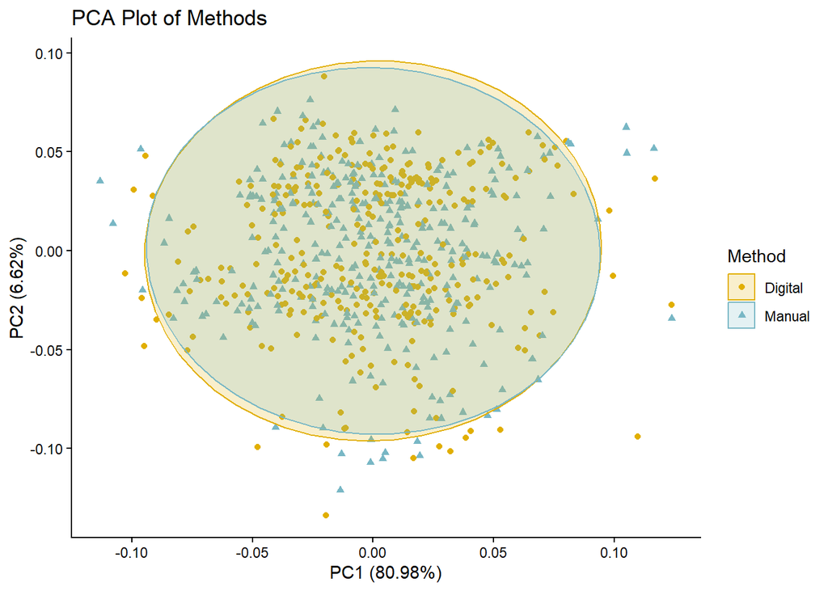

```r
digVman <- autoplot(PCA_z, data = z.wide, colour="Method", shape='Method', loadings=FALSE, loadings.label=FALSE, frame=TRUE, frame.type='norm')+scale_color_manual(values=c("#E1AF00","#78B7C5"))+ scale_fill_manual(values=c("#E1AF00","#78B7C5"))+ scale_shape_manual(values = c(16,17)) + ggtitle("PCA Plot of Methods") + theme_classic()

digVman
```

```r
ggsave(digVman, filename = "Fig7_PCA-methods.png")
```

## **Summary: Part II**

Our main goal with the Part II analysis was to compare the precision of manual and digital measurements.

Since these characteristics are not independent of each other, a more robust statistical test (than the t-tests on individual characteristics) is a repeated measures MANOVA. This allowed us to compare the manual and digital methods while treating all the characteristics as related variables. Similar to our Bland-Altman results, we see a significant difference (p<0.001). However, when we calculate the effect size, we see a small effect size (0.0267). This again illustrates that while there is a statistical difference between the two methods, this difference is not practical. Only 2.67% of the variance in our data is explained by the difference in measurement method.

Lastly, to characterize the overall shape difference and compare variation among the methods, we performed a principal component analysis. Both paired t-tests and Levene’s tests on the PC scores showed no significant difference between the two methods, corroborating our interpretation of the practical results from our previous analyses.

Overall, we conclude there is no practical difference between manual and digital measurements.

# Additional Figures & Tables

Below are additional figures and tables used in the publication.

## Part 1

```r
# COMBINED ZONE AND BASIN LEVENE'S RESULTS

levene_combined <- bind_rows(zone_result, basin_result)

levene.geo.results <- levene_combined %>%
  gt() %>%
  cols_hide(columns = "p_value") %>%
  cols_label(
    Classifier = "Classifier",
    Dimension = "Dimension",
    F_value = "F-value",
    p_display = "p-value"
  ) %>%
  fmt_markdown(columns = p_display) %>%
  fmt_number(columns = c("F_value"), decimals = 3)  %>%
  opt_horizontal_padding(scale = 2) %>%
  cols_align(align = "center", everything()) %>%
  tab_style(
    style = cell_text(weight = "bold"),
    locations = cells_body(
      columns = "p_display",
      rows = p_value < 0.05)) %>%
  tab_style(
    style = cell_borders(sides = "right", color = "lightgray", weight = px(1.5)),
    locations = cells_body(columns = c(Classifier, Dimension, F_value)))

levene.geo.results
```

| Classifier | Dimension | F-value | p-value |
| --- | --- | --- | --- |
| Zone | PC1 | 1.358 | 0.223 |
| Zone | PC2 | 4.122 | *p* < 0.001* |
| Basin | PC1 | 1.434 | 0.182 |
| Basin | PC2 | 5.688 | *p* < 0.001* |

```r
gtsave(levene.geo.results, "Table5_levene-geo-results.png")
```

```
## file:///C:/Users/allis/AppData/Local/Temp/RtmpAlID5K/file87b43a8c3b04.html screenshot completed
```

```r
# COMBINED ZONE AND BASIN VARIATION LEVELS

table_zone <- geo.df %>%
  group_by(Species, Zone) %>%
  summarise(var_dim1 = var(Dim.1, na.rm = TRUE),
            var_dim2 = var(Dim.2, na.rm = TRUE),
            .groups = "drop") %>%
  pivot_wider(names_from = Species, values_from = c(var_dim1, var_dim2)) %>%
  rename(Classifier = Zone)

table_basin <- geo.df %>%
  group_by(Species, Basin) %>%
  summarise(var_dim1 = var(Dim.1, na.rm = TRUE),
            var_dim2 = var(Dim.2, na.rm = TRUE),
            .groups = "drop") %>%
  pivot_wider(names_from = Species, values_from = c(var_dim1, var_dim2)) %>%
  rename(Classifier = Basin)

var_combined <- bind_rows(table_zone, table_basin) %>%
  mutate(
    Classifier = case_when(
      grepl("^Z", Classifier) ~ sub("^Z", "Zone ", Classifier),
      TRUE ~ Classifier))

geo.variation <- var_combined %>%
  gt() %>%
  cols_label(
    Classifier = "Classifier",
    var_dim1_p.formosa = "Amazon",
    var_dim1_p.latipinna = "Sailfin",
    var_dim2_p.formosa = "Amazon",
    var_dim2_p.latipinna = "Sailfin"
  ) %>%
  tab_spanner(label = "PC1", columns = c("var_dim1_p.latipinna", "var_dim1_p.formosa")) %>%
  tab_spanner(label = "PC2", columns = c("var_dim2_p.latipinna", "var_dim2_p.formosa")) %>%
  fmt_scientific(columns = c("var_dim1_p.latipinna", "var_dim1_p.formosa", "var_dim2_p.latipinna", "var_dim2_p.formosa"), decimals = 2) %>%
  tab_style(
    style = cell_borders(sides = "right", color = "lightgray", weight = px(1.5)),
    locations = cells_body(columns = c("Classifier", "var_dim1_p.formosa"))) %>%
  tab_style(style = cell_borders(sides = "right", color = "lightgray", weight = px(1.5)),
            locations = cells_column_labels(columns = c("var_dim1_p.formosa"))) %>%
  tab_style(
    style = cell_borders(sides = "right", color = "lightgray", weight = px(1.5)),
    locations = cells_column_spanners(spanners = c("PC1"))) %>%
  tab_style(
    style = cell_borders(sides = "right", color = "lightgray", weight = px(1), style = "dashed"),
    locations = cells_body(columns = c("var_dim1_p.latipinna", "var_dim2_p.latipinna"))) %>%
  tab_style(
  style = cell_borders(
    sides = "bottom",
    color = "darkgray",
    weight = px(2.5)),
  locations = cells_body(rows = 4)) %>%
  opt_horizontal_padding(scale=2) %>%
  cols_align(align="center", everything())


geo.variation
```

| Classifier | PC1 Sailfin | PC1 Amazon | PC2 Sailfin | PC2 Amazon |
| --- | --- | --- | --- | --- |
| Zone 1 | 1.91 × 10<sup>−4</sup> | 2.29 × 10<sup>−4</sup> | 2.98 × 10<sup>−4</sup> | 1.85 × 10<sup>−4</sup> |
| Zone 2 | 2.41 × 10<sup>−4</sup> | 1.38 × 10<sup>−4</sup> | 5.30 × 10<sup>−4</sup> | 1.02 × 10<sup>−4</sup> |
| Zone 3 | 3.46 × 10<sup>−4</sup> | 1.89 × 10<sup>−4</sup> | 2.07 × 10<sup>−4</sup> | 1.37 × 10<sup>−4</sup> |
| Zone 4 | 1.79 × 10<sup>−4</sup> | 8.78 × 10<sup>−5</sup> | 3.71 × 10<sup>−4</sup> | 1.43 × 10<sup>−4</sup> |
| Nueces-Rio Grande Coastal | 3.20 × 10<sup>−4</sup> | 1.77 × 10<sup>−4</sup> | 4.24 × 10<sup>−4</sup> | 1.65 × 10<sup>−4</sup> |
| Rio Grande | 2.08 × 10<sup>−4</sup> | 9.33 × 10<sup>−5</sup> | 1.55 × 10<sup>−4</sup> | 1.17 × 10<sup>−4</sup> |
| Panuco | 9.14 × 10<sup>−5</sup> | 1.73 × 10<sup>−4</sup> | 2.25 × 10<sup>−4</sup> | 8.01 × 10<sup>−5</sup> |
| San Fernando-Soto la Marina | 2.14 × 10<sup>−4</sup> | 1.01 × 10<sup>−4</sup> | 4.86 × 10<sup>−4</sup> | 1.19 × 10<sup>−4</sup> |
| Brazos-Colorado Coastal | 1.90 × 10<sup>−4</sup> | NA | 1.32 × 10<sup>−4</sup> | NA |

```r
gtsave(geo.variation, "Table6_geo-variation.png")
```

```
## file:///C:/Users/allis/AppData/Local/Temp/RtmpAlID5K/file87b4132e28f3.html screenshot completed
```

## Part 2

```r
#QQPLOTS BEFORE AND AFTER TRANSFORMATION

vars.man <- c("SL.man","BD1.man","CPD.man","CPL.man","PreDL.man",
          "DbL.man","HL.man","HD1.man","SnL.man","OL.man")

tiff("QQplots-man.tiff",
     width = 2400,
     height = 6000,
     res = 600,
     compression = "lzw")

par(mfcol = c(length(vars.man), 2),
    mar = c(2,2,1,1),      # small inner margins
    oma = c(2,12,4,1))      # outer margins (left + top space)

for(i in seq_along(vars.man)){

  v <- vars.man[i]

  x1 <- manual[[v]]
  x2 <- man_trans[[v]]

  p1 <- shapiro.test(x1)$p.value
  p2 <- shapiro.test(x2)$p.value

  ## Original
  qqnorm(x1, main="", pch=16, cex=0.6)
  qqline(x1, lwd=1.5)

  usr <- par("usr")

x_pos <- usr[2] - 0.05 * (usr[2] - usr[1])  # 5% inward from right
y_pos <- usr[3] + 0.05 * (usr[4] - usr[3])  # 5% upward from bottom

text(x_pos, y_pos,
     labels = paste0("p = ", format.pval(p1, digits=3)),
     adj = c(1,0),
     cex = 0.8)

  ## Transformed
  qqnorm(x2, main="", pch=16, cex=0.6)
  qqline(x2, lwd=1.5)

  usr <- par("usr")

x_pos <- usr[2] - 0.05 * (usr[2] - usr[1])  # 5% inward from right
y_pos <- usr[3] + 0.05 * (usr[4] - usr[3])  # 5% upward from bottom

text(x_pos, y_pos,
     labels = paste0("p = ", format.pval(p1, digits=3)),
     adj = c(1,0),
     cex = 0.8)

  mtext(v,
        side=2,
        line=6,
        at = 1 - (i - 0.5)/length(vars.man),
        outer=TRUE,
        las=2,
        cex=0.9)
}
# Column headers
mtext("Original", side = 3, line = 1.5, at = 0.27, outer = TRUE, cex = 1.2)
mtext("Transformed", side = 3, line = 1.5, at = 0.73, outer = TRUE, cex = 1.2)

dev.off()
```

```r
##############

vars.dig <- c("SL.dig","BD1.dig", "BD2.dig","CPD.dig","CPL.dig","PreDL.dig",
          "DbL.dig","HL.dig","HD1.dig", "HD2.dig","SnL.dig","OL.dig")

tiff("QQplots-dig.tiff",
     width = 2400,
     height = 6000,
     res = 600,
     compression = "lzw")

par(mfcol = c(length(vars.dig), 2),
    mar = c(2,2,1,1),      # small inner margins
    oma = c(2,12,4,1))      # outer margins (left + top space)

for(i in seq_along(vars.dig)){

  v <- vars.dig[i]

  x1 <- digital[[v]]
  x2 <- dig_trans[[v]]

  p1 <- shapiro.test(x1)$p.value
  p2 <- shapiro.test(x2)$p.value

  ## Original
  qqnorm(x1, main="", pch=16, cex=0.6)
  qqline(x1, lwd=1.5)

  usr <- par("usr")

x_pos <- usr[2] - 0.05 * (usr[2] - usr[1])  # 5% inward from right
y_pos <- usr[3] + 0.05 * (usr[4] - usr[3])  # 5% upward from bottom

text(x_pos, y_pos,
     labels = paste0("p = ", format.pval(p1, digits=3)),
     adj = c(1,0),
     cex = 0.8)

  ## Transformed
  qqnorm(x2, main="", pch=16, cex=0.6)
  qqline(x2, lwd=1.5)

  usr <- par("usr")

x_pos <- usr[2] - 0.05 * (usr[2] - usr[1])  # 5% inward from right
y_pos <- usr[3] + 0.05 * (usr[4] - usr[3])  # 5% upward from bottom

text(x_pos, y_pos,
     labels = paste0("p = ", format.pval(p1, digits=3)),
     adj = c(1,0),
     cex = 0.8)

  mtext(v,
        side=2,
        line=6,
        at = 1 - (i - 0.5)/length(vars.dig),
        outer=TRUE,
        las=2,
        cex=0.9)
}
# Column headers
mtext("Original", side = 3, line = 1.5, at = 0.27, outer = TRUE, cex = 1.2)
mtext("Transformed", side = 3, line = 1.5, at = 0.73, outer = TRUE, cex = 1.2)

dev.off()
```

```r
#POST PCA TESTS IN ONE TABLE
post.pca.combo <- bind_rows(ttest_result, levenes_result_meth) %>%
 mutate(Test_Statistic = case_when(
      Classifier == "T-test"       ~ paste0("t = ", sprintf("%.3f", t_value)),
      Classifier == "Levene's Test" ~ paste0("F = ", sprintf("%.3f", F_value))))

post.pca.tbl <- post.pca.combo %>%
  gt() %>%
  cols_hide(columns = c("F_value", "t_value", "p_value")) %>%
  cols_move_to_start(columns = c(Classifier, Dimension, Test_Statistic)) %>%
  cols_label(
    Classifier = "Test type",
    Dimension = "Dimension",
    Test_Statistic = "Test statistic",
    p_display = "p-value") %>%
  fmt_markdown(columns = p_display) %>%
  opt_horizontal_padding(scale = 2) %>%
  cols_align(align = "center", everything()) %>%
  tab_style(
    style = cell_text(weight = "bold"),
    locations = cells_body(
      columns = "p_display",
      rows = p_value < 0.05)) %>%
  tab_style(
    style = cell_borders(sides = "right", color = "lightgray", weight = px(1.5)),
    locations = cells_body(columns = c(Classifier, Dimension, Test_Statistic)))

post.pca.tbl
```

| Test type | Dimension | Test statistic | p-value |
| --- | --- | --- | --- |
| T-test | PC1 | t = 0.000 | 1.000 |
| T-test | PC2 | t = -0.000 | 1.000 |
| Levene's Test | PC1 | F = 0.002 | 0.961 |
| Levene's Test | PC2 | F = 1.764 | 0.185 |

```r
gtsave(post.pca.tbl, "Table8_post-pca-methods.png")
```

```
## file:///C:/Users/allis/AppData/Local/Temp/RtmpAlID5K/file87b44affde2.html screenshot completed
```